# How do we do Bayes: a really brief primer

Joshua Harrison, Andrew Seifert, with input from Eryn McFarlane and Christopher Weiss-Lehman

# A window into the world of Bayes using R, Stan, and Rstan

*Acknowledgment: much of the code here was copied from the internet. Most of the places I pulled code said they copied it from somewhere else. If the o.g. author is apparent then I will post that in comments within code blocks.*

Outline

- What do we need to do to run a Bayesian model?
  - Specify distributions for the likelihood and prior (defining the model)
  - Get samples from the posteriors of parameters of interest using a sampling algorithm
  - Examine the samples to make sure we have converged.

If you are new and the terminology mentioned in the outline is not clear, do not fear! Hopefully, this example will help. This script is designed as an appetizer, to show that specifying a model can be straightforward. To be fluent in Bayesian statistics does not come overnight, so be reasonable with yourself as you are learning this. For most people, it takes a while to feel comfortable with the different moving parts of doing Bayesian analysis. And, even for those of us that have done this for awhile, it requires considerable review to make totally different models from scratch. One idea is to first be able to get this code to run and understand it. Then, one can google and find many, many models already coded up that one can use. Finally, this should give one the experience to start making a bespoke model.

This code relies on Stan and Rstan. This is what wikipedia says about Stan: “Stan is a probabilistic programming language for statistical inference written in C++. The Stan language is used to specify a (Bayesian) statistical model with an imperative program calculating the log probability density function.” To unpack this, Stan uses a specific syntax to specify a model, which it then turns into a compiled piece of software. When we write code for Stan, we are not writing R or Python, but writing Stan code.

Rstan is a handy package that lets us call up a compiled Stan model from R.

Installing Stan and Rstan can be cumbersome, depending on your computer. For help with this, send up a flag and somebody in the Data Science crew can try and help.

# Let’s make a model

Say we want to estimate the mean of some data that look normally distributed (the good ol’ Bell curve looking thing, see below). We could calculate the mean of the data using the formula we all know and love, but what if we want to know how certain we are in the mean, given our data? Another way of saying this we want to know the probability of our model given the data. The value of the mean is our model. It is a really simple model, but a model nonetheless. This is because we are hypothesizing that our data are sampled from a distribution with some mean. Lets make some data to illustrate:

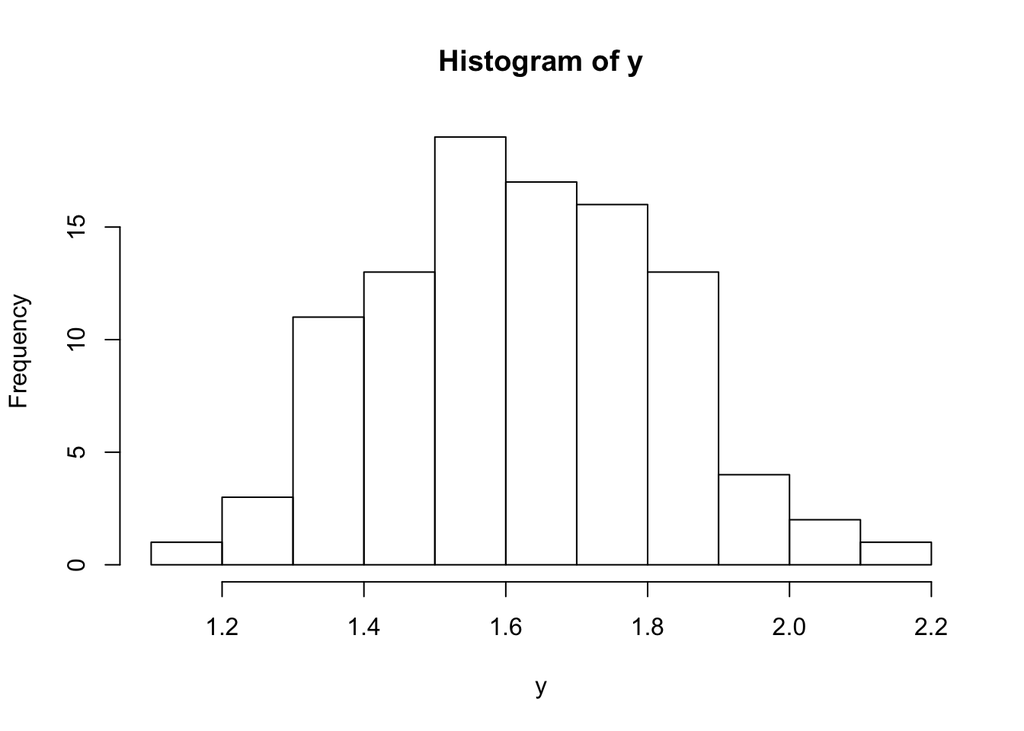

```r
y <- rnorm(n = 100, #Number of deviates
          mean = 1.6, #Mean of distribution
          sd = 0.2) #Standard deviation of the distribution

hist(y)
```

So, for this histogram, we pulled 100 numbers from a normal distribution that had a mean of 1.6 and a standard deviation of 0.2. Cool. But what if we didn’t know what the mean and standard deviation of the distribution was, instead all we had were the actual data. *This is the situation we are normally in as scientists*. We go measure some data (like tree heights) and have to figure out the mean of those data.

So say all we had were those 100 numbers I generated above.

```r
head(y)
```

```
## [1] 1.472375 1.342425 1.601624 1.255270 1.478290 1.453052
```

And we wanted to estimate the mean. We could estimate via maximum likelihood, which is simply summing all these numbers and dividing by how many numbers there are (our usual approach).

```r
sum(y) / length(y) #or mean(y)
```

```
## [1] 1.618921
```

The denominator is the probability of the data. The reason that is there is to normalize the product of the likelihood and the prior so that it integrates to one. Remember that probability distributions need to integrate to one (if this is a new concept, then check out some reading on probability distributions).

We can leave out this normalizing constant if want and say that the posterior is proportional to the likelihood times the prior. Folks like to do this because figuring out the probability of the data can be hard.
$$Pr(\theta | y) \propto Pr(y | \theta) Pr(\theta)$$
Note here that we are talking about probability *distributions*, not just single values.

Ok, so we need to substitute in our model and data into this theorem. Let’s focus on the right hand side…we need to calculate the probability of our data given our model (mean of 1.6, see above) and assign a prior probability distribution to the model.

We can make any prior distribution we want. We could say that we are really sure that 1.6 is a good model, or we could say that 1.6 is probably good, but we aren’t super sure. Or, we could say, we have no damn idea what our model should be other than the mean of some normal distribution. I am gonna go with option one for now. If you are keen, then tweak this code to try out the other options (hint, mess with the variance and means of the priors).

Next, we have to characterize these different prior probability distributions. As strange as it may seem, we can just pick values for our model, meaning we can pick values for the mean and standard deviation that we think the data may have come from. Let’s do this in the context of a specified Stan model.

Recall that Stan let’s us specify a model and does all the calculations for us. That is why I am using it here instead of using the probability density functions (PDF) of the normal distribution. Here is an example where someone does use the probability density functions: https://bookdown.org/kevin_davisross/bayesian-reasoning-and-methods/mean.html.

But I don’t want to write that much math right now . :) Note, that if using PDFs is an unfamiliar concept, then it would be worth googling that a bit and getting familiar with it. I just scanned this resource and it may be helpful (though a vast many others exist too): https://www.econometrics-with-r.org/2-1-random-variables-and-probability-distributions.html

Stan, conveniently deals with all this for us. Notably, in some cases calculating probabilities via formula that provide solutions of certain forms (meaning that have understood distributions) may be super hard or impossible, Stan helps us out here too, as we will see.